# Machine Learning Project

Obinna F. Ezeibekwe

5/27/2021

## Data Collection and Wrangling

I start by loading the required R packages that will enable me to do the analysis for this project. Specifically, I losded packages such as *caret*, *randomForest*, *rpart* and *rpart.plot*. Then, I use the set.seed() command so that my result can be reproduced. The next step is to download the data from a website and also replace missing values with **NA**. I checked the dimension of the data and looked at the first few rows.

The next phase of the data cleaning is to delete columns with all missing values. This operation removes 100 columns from the dataset. Also, I remove seven irrelevant variables so that we are left with 53 variables.

```r
set.seed(66651)


#Download the dataset from online source and replace all missing data with "NA"
trainingURL <- read.csv("https://d396qusza40orc.cloudfront.net/predmachlearn/pml-training.csv", na.strings = c("NA", "#DIV/0!", ""))
testingURL <- read.csv("https://d396qusza40orc.cloudfront.net/predmachlearn/pml-testing.csv", na.strings = c("NA", "#DIV/0!", ""))

dim(trainingURL)
```

```
## [1] 19622   160
```

```r
dim(testingURL)
```

```
## [1]  20 160
```

```r
#head(trainingURL)

#Delete columns with all missing values
trainingURL <- trainingURL[, colSums(is.na(trainingURL)) == 0]
testingURL <- testingURL[, colSums(is.na(testingURL)) == 0]

dim(trainingURL)
```

```
## [1] 19622    60
```

```r
dim(testingURL)
```

```
## [1] 20 60
```

```r
trainingURL   <-trainingURL[, -c(1:7)]
testingURL <-testingURL[, -c(1:7)]

dim(trainingURL)
```

```
## [1] 19622    53
```

```r
dim(testingURL)
```

```
## [1] 20 53
```

## Partitioning the *trainingURL* data set to allow cross-validation

The *trainingURL* data set contains 53 variables and 19622 obs while the testingURL data set contains 53 variables and 20 obs. To perform cross-validation, the *trainingURL* data set is partitioned into two sets - training (70%) and testing (30%).

The dependent variable *classe* contains 5 categories: A, B, C, D, and E. For this data set, “participants were asked to perform one set of 10 repetitions of the Unilateral Dumbbell Biceps Curl in 5 different fashions: exactly according to the specification (Class A), throwing the elbows to the front (Class B), lifting the dumbbell only halfway (Class C), lowering the dumbbell only halfway (Class D), and throwing the hips to the front (Class E).

I use the *ggplot* command to plot it to see the frequency of each category in the training data set. The plot shows that the categories are relatively equal to each other except category A.

```
## [1] 13737    53
```

```
## [1] 5885   53
```

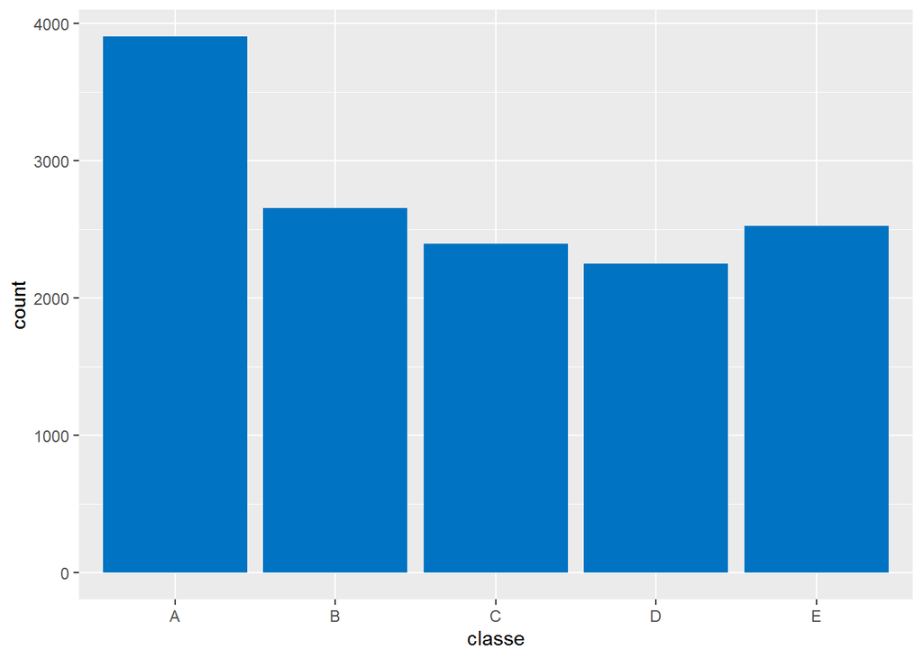

## First prediction model: Using Decision Tree

The result shows that the accuracy of this model is 0.744 with a 95 percent confidence interval of 0.7331 to 0.7555.

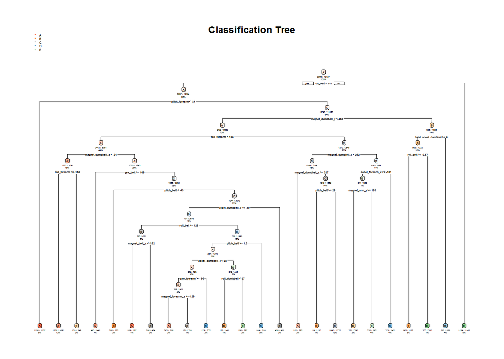

```r
mod1 <- rpart(classe ~ ., data = training, method = "class")

# Prediction
pred1 <- predict(mod1, testing, type = "class")

# Plot of the Decision Tree
rpart.plot(mod1, main = "Classification Tree", extra = 102, under = TRUE,
           faclen = 0)
```

```r
# Test results on our testing data set
confusionMatrix(factor(pred1), factor(testing$classe))
```

```
## Confusion Matrix and Statistics
##
##           Reference
## Prediction    A    B    C    D    E
##          A 1487  200   30   58   43
##          B   71  697  104   90   98
##          C   27  100  807  148  101
##          D   64   86   50  596   46
##          E   25   56   35   72  794
##
## Overall Statistics
##
##                Accuracy : 0.7444
##                  95% CI : (0.7331, 0.7555)
##     No Information Rate : 0.2845
##     P-Value [Acc > NIR] : < 2.2e-16
##
##                   Kappa : 0.6757
##
##  Mcnemar's Test P-Value : < 2.2e-16
##
## Statistics by Class:
##
##                      Class: A Class: B Class: C Class: D Class: E
## Sensitivity            0.8883   0.6119   0.7865   0.6183   0.7338
## Specificity            0.9214   0.9235   0.9226   0.9500   0.9609
## Pos Pred Value         0.8179   0.6575   0.6822   0.7078   0.8086
## Neg Pred Value         0.9540   0.9084   0.9534   0.9270   0.9413
## Prevalence             0.2845   0.1935   0.1743   0.1638   0.1839
## Detection Rate         0.2527   0.1184   0.1371   0.1013   0.1349
## Detection Prevalence   0.3089   0.1801   0.2010   0.1431   0.1669
## Balanced Accuracy      0.9048   0.7677   0.8546   0.7841   0.8473
```

## Second prediction model: Using Random Forest

The result shows that the accuracy of this model is 0.996 with a 95 percent confidence interval of 0.9946 to 0.9978. The Random Forest algorithm performed better than Decision Trees because of better accuracy. The expected out-of-sample error, calculated as 1 - accuracy for predictions made against the cross-validation set, is 0.0036. The test data set comprises 20 cases with an accuracy rate that is above 99% on our cross-validation data. This suggests that most of the test samples will be correctly classified.

```r
mod2 <- randomForest(factor(classe) ~ ., data = training, method = "class")

#Prediction
pred2 <- predict(mod2, testing, type = "class")

#Test results on testing data set
confusionMatrix(factor(pred2), factor(testing$classe))
```

```
## Confusion Matrix and Statistics
##
##           Reference
## Prediction    A    B    C    D    E
##          A 1674    2    0    0    0
##          B    0 1137    5    0    0
##          C    0    0 1021   12    1
##          D    0    0    0  951    0
##          E    0    0    0    1 1081
##
## Overall Statistics
##
##                Accuracy : 0.9964
##                  95% CI : (0.9946, 0.9978)
##     No Information Rate : 0.2845
##     P-Value [Acc > NIR] : < 2.2e-16
##
##                   Kappa : 0.9955
##
##  Mcnemar's Test P-Value : NA
##
## Statistics by Class:
##
##                      Class: A Class: B Class: C Class: D Class: E
## Sensitivity            1.0000   0.9982   0.9951   0.9865   0.9991
## Specificity            0.9995   0.9989   0.9973   1.0000   0.9998
## Pos Pred Value         0.9988   0.9956   0.9874   1.0000   0.9991
## Neg Pred Value         1.0000   0.9996   0.9990   0.9974   0.9998
## Prevalence             0.2845   0.1935   0.1743   0.1638   0.1839
## Detection Rate         0.2845   0.1932   0.1735   0.1616   0.1837
## Detection Prevalence   0.2848   0.1941   0.1757   0.1616   0.1839
## Balanced Accuracy      0.9998   0.9986   0.9962   0.9933   0.9994
```

## Predict outcome levels on the original testing data set, *testingURL*, using Random Forest

```r
predfinal <- predict(mod2, testingURL, type = "class")
predfinal
```

```
##  1  2  3  4  5  6  7  8  9 10 11 12 13 14 15 16 17 18 19 20
##  B  A  B  A  A  E  D  B  A  A  B  C  B  A  E  E  A  B  B  B
## Levels: A B C D E
```